# Transcription factor (TF) binding frequency

Kasit Chatsirisupachai

2024-06-26

# Introduction

As you have learned within the course already, we can use SMF to study protein-DNA bindings, as examplified by RNA polymerase II (Pol II). In this exercise, we will leverage SMF to study the binding of transcription factors (TF) to DNA. The principle of the analysis is very similar to our Pol II example. Basically, you have to do the context methylation calling. Then, you will perform single-molecule sorting of each read, to assign molecular states (e.g. nucleosome, unbound, TF bound).

Here, we have a dataset of mouse embryonic stem cells (mESCs) “Control” and the mESCs with the transcription factor “REST” knocked out (REST KO). We will study REST bindings at their binding sites comparing between these two condition. These data sets come from one of the papers we sent to you earlier (Sonmezer et al., Mol. Cell, 2021). You can have a look at the Figure 2 in the paper.

## Data

The data sets include the control and the REST K/O samples. The control sample is a targeted amplicon DUAL-enzyme SMF (GpC and CpG) on selected mouse transcription factor binding sites (TFBSs) of mESC TKO cell line. The REST K/O is a targeted amplicon SINGLE-enzyme SMF (only GpC) on TFBSs. SMF library were sequenced in paired-end using Illumina platform. Once obtain the raw sequencing data, Fastq files were aligned to the mouse mm10 genome using `QuasR` package.

## Libraries

First of all, if you haven’t done so, don’t forget to install the BSgenome package for mouse genome using the below code

```r
#BiocManager::install("BSgenome.Mmusculus.UCSC.mm10")
```

Once installed, let’s load the necessary packages.

```r
library(QuasR)
library(SingleMoleculeFootprinting)
```

```r
library(BSgenome.Mmusculus.UCSC.mm10)
library(tidyverse)
library(ggplot2)
```

## Load objects

First, we will load the GRanges object containing the binding sites for REST.

```r
REST_TFBS <- readRDS("/g/krebs/chatsiri/SMF_tutorial/data/dataset_4_TF_cooccupancy/REST_TFBSs.rds")
head(REST_TFBS)
```

```
## GRanges object with 6 ranges and 3 metadata columns:
##               seqnames              ranges strand |        name          TF
##                  <Rle>           <IRanges>  <Rle> | <character> <character>
##   TFBS_119393     chr1   59423121-59423141      + |        REST        REST
##   TFBS_269739     chr1 127496935-127496955      + |        REST        REST
##   TFBS_921564     chr2   28916189-28916209      + |        REST        REST
##   TFBS_921565     chr2   28916264-28916284      + |        REST        REST
##   TFBS_932810     chr2   33018214-33018234      + |        REST        REST
##   TFBS_932811     chr2   33018235-33018255      + |        REST        REST
##               absolute.idx
##                <character>
##   TFBS_119393  TFBS_119393
##   TFBS_269739  TFBS_269739
##   TFBS_921564  TFBS_921564
##   TFBS_921565  TFBS_921565
##   TFBS_932810  TFBS_932810
##   TFBS_932811  TFBS_932811
##   -------
##   seqinfo: 66 sequences (1 circular) from mm10 genome
```

Next, we will load also the GRanges object containing the amplicon locations we will be working with.

```r
amplicon_REST <- readRDS("/g/krebs/chatsiri/SMF_tutorial/data/dataset_4_TF_cooccupancy/Amplicon_REST_regions.rds")
head(amplicon_REST)
```

```
## GRanges object with 6 ranges and 7 metadata columns:
##          seqnames              ranges strand |        ID
##             <Rle>           <IRanges>  <Rle> | <numeric>
##   AMP_10     chr2   28915921-28916411      * |        10
##   AMP_11     chr2   33017990-33018487      * |        11
##   AMP_12     chr4   46992856-46993354      * |        12
##   AMP_13     chr4 127619732-127620226      * |        13
##   AMP_14     chr5 134544786-134545270      * |        14
##   AMP_15    chr19   54175783-54176277      * |        15
##          Forward.Primer.Sequence Forward.Primer.Sequence.1    Plate_ID
##                      <character>               <character> <character>
##   AMP_10      GGGAGTGTTAGGAGGAAT      AAAAACAACAACAACAACAA     Plate_1
##   AMP_11    AGGTGATAAGAGAAGGTAGA    CCTAAATTTCCTTTCCTATA..     Plate_1
##   AMP_12  TTTTTAAAAGGAGGATATGGAG      ACCCACAATAAAACTCAAAA     Plate_1
##   AMP_13  GTGTTTATGTTATAGAGATT..    AATAATTTAAAACTCAAAAC..     Plate_1
##   AMP_14  TTAGGAGGATATTTAAATTGGT       AAAATATCACCTCACCCAA     Plate_1
##   AMP_15    GTGTGAAGGGATATAAGGAA      CAATCTCATCAAATTCCTCT     Plate_1
##           TargetType    TargetTF    TargetSite
##          <character> <character>   <character>
##   AMP_10    SingleTF        REST   TFBS_921564
##   AMP_11    SingleTF        REST   TFBS_932810
##   AMP_12    SingleTF        REST  TFBS_2505232
##   AMP_13    SingleTF        REST  TFBS_2680517
##   AMP_14    SingleTF        REST  TFBS_3394835
##   AMP_15    SingleTF        REST TFBS_10873850
##   -------
##   seqinfo: 19 sequences from an unspecified genome; no seqlengths
```

Notice that we can locate the binding site of REST within each amplicon region by connecting the `TargetSite` column in the `amplicon_REST` object with the `absolute.idx` column in the `REST_TFBS` object.

#### Question 1:

How many amplicon regions we are looking at? and What is the average width of these amplicon regions in the `amplicon_REST` object?

Answer:

Hint: use function `length()`, `width()` and `mean()`

Let’s start analysing the data! As always, we need to load Qinput files. In this example, we will have two Qinput files, one for the Control sample and the other for the REST_KO sample. We will analyse each of them separately. The reason for this is that the Control sample was footprinted using both GpC and CpG enzymes, while the REST_KO sample was footprinted only by GpC enzyme.

!!! DON’T FORGET TO CHANGE THE ABSOLUTE PATH IN THE QINPUT FILES TO YOUR OWN PATH. (remember we had this problem during the course) !!!

```r
Qinput_Control <- "/g/krebs/chatsiri/SMF_tutorial/analysis/example_4/Qinput_Control.txt"
Qinput_REST_KO <- "/g/krebs/chatsiri/SMF_tutorial/analysis/example_4/Qinput_REST_KO.txt"
```

## One region as an example

We will first take a look at the first amplicon region in a Control sample, as an example.

```r
MySample <- suppressMessages(readr::read_delim(Qinput_Control, delim = "\t")[[2]])

genome <- BSgenome.Mmusculus.UCSC.mm10

gr <- amplicon_REST[1]
print(gr)
```

```
## GRanges object with 1 range and 7 metadata columns:
##          seqnames            ranges strand |        ID Forward.Primer.Sequence
##             <Rle>         <IRanges>  <Rle> | <numeric>             <character>
##   AMP_10     chr2 28915921-28916411      * |        10      GGGAGTGTTAGGAGGAAT
##          Forward.Primer.Sequence.1    Plate_ID  TargetType    TargetTF
##                        <character> <character> <character> <character>
##   AMP_10      AAAAACAACAACAACAACAA     Plate_1    SingleTF        REST
##           TargetSite
##          <character>
##   AMP_10 TFBS_921564
##   -------
##   seqinfo: 19 sequences from an unspecified genome; no seqlengths
```

### Call context methylation

```r
Methylation <- CallContextMethylation(sampleSheet = Qinput_Control,
                                      sample = MySample,
                                      genome = genome,
                                      RegionOfInterest = gr,
                                      coverage = 20,
                                      ConvRate.thr = 0.2,
                                      returnSM = TRUE,
                                      clObj = 1)
```

```
## Setting QuasR project
```

```
## all necessary alignment files found
```

```
## Calling methylation at all Cytosines
```

```
## checking if RegionOfInterest contains information at all
```

```
## Discard immediately the cytosines not covered in any sample
```

```
## Extracting single molecule matrix
```

```
## 0% of reads found with conversion rate below 0.2
```

```
## Subsetting Cytosines by permissive genomic context (GC, HCG)
```

```
## Collapsing strands
```

```
## 0 reads found mapping to the - strand, collapsing to +
## 0 reads found mapping to the - strand, collapsing to +
```

```
## Filtering Cs for coverage
```

```
## Detected experiment type: DE
```

```
## Subsetting Cytosines by strict genomic context (GCH, GCG, HCG) based on the detected experiment type: DE
```

```
## Merging matrixes
```

### Plot average methylation

```
## No sorted reads passed...plotting counts from all reads
```

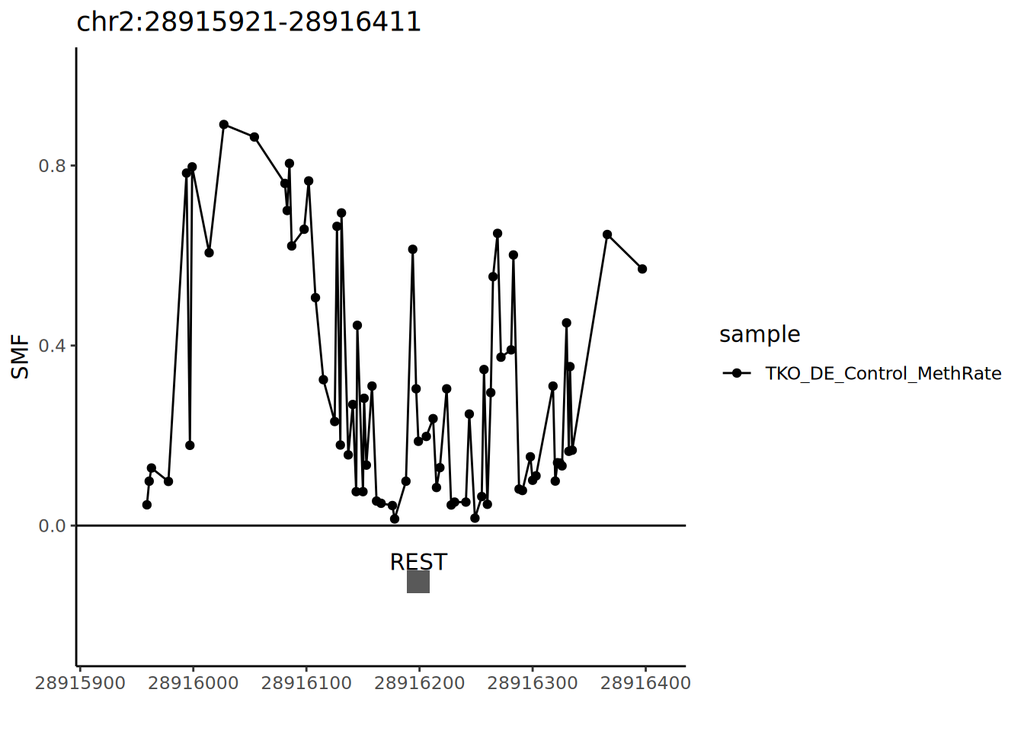

```r
# locate REST binding sites
TFBS <- REST_TFBS[REST_TFBS$absolute.idx == gr$TargetSite]

PlotAvgSMF(MethGR = Methylation[[1]],
           RegionOfInterest = gr,
           TFBSs = TFBS)
```

#### Question 2:

What does each dot in the plot represent? What is the y axis, how does it relate to average methylation level?

Answer:

### Single-molecule sorting

Similar to the Pol II example previously, we can assign molecular state to each read. However, unlike the 4-bin strategy in the Pol II example, the TF binding is simpler. We will use the 3-bin strategy: the middle bin represents the TFBS and flanking by the other two bins.

From 3 bins, there can be 8 molecular states in total (`000`, `001`, `010`, `011`, `100`, `101`, `110`, and `111`). We will define 3 TF binding states from these 8 total states. 1) TF-bound: `101`, 2) unbound: `111`, and 3) nucleosome-bound: the other 6 states.

Okay, let’s now do the sorting. Remember we need to define the bins. Here, I will use the function `MakeBins` as we previously used, but this time with the `singleTF` BinType. Notice that with TF we don’t need to use StrandAware option like in the Pol II example.

```r
BinsCoordinates <- MakeBins(RegionsOfInterest = TFBS, BinType = "singleTF", StrandAware = FALSE)
```

```
## Designing sorting bins
```

```r
SortedReads <- list(TKO_DE_Control = SortReads(Methylation[[2]]$TKO_DE_Control, BinsCoordinates, coverage = 20))
```

```
## Subsetting those reads that cover all bins
```

```
## Summarizing reads into patterns
```

```
## Splitting reads by pattern
```

We can define molecular states of TF binding as discussed.

```r
TF_states <- list(nucleosome = c("000", "001", "010", "011", "100", "110"),
                  unbound = "111",
                  TF_bound = "101")
```

Finally, we can quantify state frequency of nucleosome, unbound, and TF-bound states.

#### Question 3:

Have a look at the SortedReads object, how many reads are there in the unbound and TF-bound states? And what are the frequency of unbound and TF-bound states?

Answer:

Hint: use the `StateQuantification` function with the `TF_states` we just defined above as a parameter `states`.

## REST KO sample

Now, it’s time to analyse the REST_KO sample to compare REST binding frequency in this example region.

```r
MySample <- suppressMessages(readr::read_delim(Qinput_REST_KO, delim = "\t")[[2]])

genome <- BSgenome.Mmusculus.UCSC.mm10

gr <- amplicon_REST[1]
print(gr)
```

```
## GRanges object with 1 range and 7 metadata columns:
##          seqnames            ranges strand |        ID Forward.Primer.Sequence
##             <Rle>         <IRanges>  <Rle> | <numeric>             <character>
##   AMP_10     chr2 28915921-28916411      * |        10      GGGAGTGTTAGGAGGAAT
##          Forward.Primer.Sequence.1    Plate_ID  TargetType    TargetTF
##                        <character> <character> <character> <character>
##   AMP_10      AAAAACAACAACAACAACAA     Plate_1    SingleTF        REST
##           TargetSite
##          <character>
##   AMP_10 TFBS_921564
##   -------
##   seqinfo: 19 sequences from an unspecified genome; no seqlengths
```

### Call context methylation

Again, we perform call context methylation on the REST_KO sample. As it is a single-enzyme treatment (only GpC), the `CallContextMethylation` function returns two contexts (GpC and CpG) separately.

```r
Methylation <- CallContextMethylation(sampleSheet = Qinput_REST_KO,
                                      sample = MySample,
                                      genome = genome,
                                      RegionOfInterest = gr,
                                      coverage = 20,
                                      ConvRate.thr = 0.2,
                                      returnSM = TRUE,
                                      clObj = 1)
```

```
## Setting QuasR project
```

```
## all necessary alignment files found
```

```
## Calling methylation at all Cytosines
```

```
## checking if RegionOfInterest contains information at all
```

```
## Discard immediately the cytosines not covered in any sample
```

```
## Extracting single molecule matrix
```

```
## 0% of reads found with conversion rate below 0.2
```

```
## Subsetting Cytosines by permissive genomic context (GC, HCG)
```

```
## Collapsing strands
```

```
## 0 reads found mapping to the - strand, collapsing to +
## 0 reads found mapping to the - strand, collapsing to +
```

```
## Filtering Cs for coverage
```

```
## Detected experiment type: NO
```

```
## Subsetting Cytosines by strict genomic context (DGCHN, -, NWCGW) based on the detected experiment type: NO
```

```
## Returning non merged matrixes
```

```r
print("GC context")
```

```
## [1] "GC context"
```

```r
print(head(Methylation[[1]]$DGCHN))
```

```
## GRanges object with 6 ranges and 3 metadata columns:
##       seqnames    ranges strand | REST_NO_KO_Coverage REST_NO_KO_MethRate
##          <Rle> <IRanges>  <Rle> |           <integer>           <numeric>
##   [1]     chr2  28915978      + |                 120            0.516667
##   [2]     chr2  28915997      + |                 120            0.491667
##   [3]     chr2  28916014      + |                 119            0.420168
##   [4]     chr2  28916098      + |                 119            0.327731
##   [5]     chr2  28916108      + |                 118            0.313559
##   [6]     chr2  28916115      + |                 116            0.405172
##       GenomicContext
##          <character>
##   [1]          DGCHN
##   [2]          DGCHN
##   [3]          DGCHN
##   [4]          DGCHN
##   [5]          DGCHN
##   [6]          DGCHN
##   -------
##   seqinfo: 239 sequences (1 circular) from mm10 genome
```

```r
print("CG context")
```

```
## [1] "CG context"
```

```r
print(head(Methylation[[1]]$NWCGW))
```

```
## GRanges object with 4 ranges and 3 metadata columns:
##       seqnames    ranges strand | REST_NO_KO_Coverage REST_NO_KO_MethRate
##          <Rle> <IRanges>  <Rle> |           <integer>           <numeric>
##   [1]     chr2  28916027      + |                 119          0.00840336
##   [2]     chr2  28916054      + |                 119          0.01680672
##   [3]     chr2  28916224      + |                 107          0.05607477
##   [4]     chr2  28916366      + |                 120          0.06666667
##       GenomicContext
##          <character>
##   [1]          NWCGW
##   [2]          NWCGW
##   [3]          NWCGW
##   [4]          NWCGW
##   -------
##   seqinfo: 239 sequences (1 circular) from mm10 genome
```

#### Question 4:

Can you repeat the above average SMF plot that we did for the Control sample on the REST_KO sample? Don’t forget to only select for the GC context for plotting.

What do you observe?

Answer:

You can type on the below code chunck for plotting.

### Single-molecule sorting

Similar to the control sample, we can sort each DNA molecule in different states (nucleosome, unbound, TF-bound). Again, we only use information from the GC context.

```r
BinsCoordinates <- MakeBins(RegionsOfInterest = TFBS, BinType = "singleTF", StrandAware = FALSE)
```

```
## Designing sorting bins
```

```r
SortedReads <- list(REST_NO_KO = SortReads(Methylation[[2]]$REST_NO_KO$DGCHN, BinsCoordinates, coverage = 20))
```

```
## Subsetting those reads that cover all bins
```

```
## Summarizing reads into patterns
```

```
## Splitting reads by pattern
```

#### Question 5:

Have a look at the SortedReads object, do you observe any REST-bound state?

Answer:

Hint: use the `StateQuantification` function with the `TF_states` as a parameter `states`.

## Working with multiple REST binding sites

Now, we will simultaneously quantify REST binding states in multiple REST binding sites.

### Control sample

```r
MySample <- suppressMessages(readr::read_delim(Qinput_Control, delim = "\t")[[2]])
genome <- BSgenome.Mmusculus.UCSC.mm10


# this would take some time to run.
SortedReads_Control <- lapply(seq_along(amplicon_REST), function(i) {
  CurrentWindow <- amplicon_REST[i]
  print(paste0("Working on: region ", i))

  ExperimentType <- suppressMessages(SingleMoleculeFootprinting::DetectExperimentType(Samples = MySample))

  # Call context methylation
  Methylation <- CallContextMethylation(sampleSheet = Qinput_Control,
                                        sample = MySample,
                                        genome = genome,
                                        RegionOfInterest = CurrentWindow,
                                        coverage = 20,
                                        ConvRate.thr = 0.2,
                                        returnSM = TRUE)

  # locate REST binding sites and make bins
  TFBS <- REST_TFBS[REST_TFBS$absolute.idx == CurrentWindow$TargetSite]
  BinsCoordinates <- MakeBins(RegionsOfInterest = TFBS, BinType = "singleTF", StrandAware = FALSE)

  # Sort reads
  SortedReads_window <- list(TKO_DE_Control = SortReads(Methylation[[2]]$TKO_DE_Control, BinsCoordinates, coverage = 20))

  names(SortedReads_window) <- names(amplicon_REST[i])

  return(SortedReads_window)
  })
```

```
## [1] "Working on: region 1"
## [1] "Working on: region 2"
## [1] "Working on: region 3"
## [1] "Working on: region 4"
## [1] "Working on: region 5"
## [1] "Working on: region 6"
## [1] "Working on: region 7"
## [1] "Working on: region 8"
## [1] "Working on: region 9"
## [1] "Working on: region 10"
## [1] "Working on: region 11"
## [1] "Working on: region 12"
## [1] "Working on: region 13"
## [1] "Working on: region 14"
## [1] "Working on: region 15"
## [1] "Working on: region 16"
## [1] "Working on: region 17"
## [1] "Working on: region 18"
## [1] "Working on: region 19"
```

```r
SortedReads_Control <- unlist(SortedReads_Control, recursive = FALSE)

# Calculate state frequencies
StateFrequency_Control <- Reduce(rbind, lapply(seq_along(SortedReads_Control),
        function(i) {
            StateQuantification_tbl = StateQuantification(SortedReads = SortedReads_Control[i], states = TF_states)
            StateQuantification_tbl
            }
        ))

StateFrequency_Control <- drop_na(StateFrequency_Control)
print(head(StateFrequency_Control))
```

```
## # A tibble: 6 × 4
##   Sample State      Counts Freqs
##   <chr>  <chr>       <int> <dbl>
## 1 AMP_10 nucleosome     38  19.9
## 2 AMP_10 unbound       126  66.0
## 3 AMP_10 TF_bound       27  14.1
## 4 AMP_11 nucleosome    319  53.3
## 5 AMP_11 unbound       152  25.4
## 6 AMP_11 TF_bound      128  21.4
```

### REST_KO sample

```r
MySample <- suppressMessages(readr::read_delim(Qinput_REST_KO, delim = "\t")[[2]])
genome <- BSgenome.Mmusculus.UCSC.mm10


# this would take some time to run.
SortedReads_REST_KO <- lapply(seq_along(amplicon_REST), function(i) {
  CurrentWindow <- amplicon_REST[i]
  print(paste0("Working on: region ", i))

  ExperimentType <- suppressMessages(SingleMoleculeFootprinting::DetectExperimentType(Samples = MySample))

  # Call context methylation
  Methylation <- CallContextMethylation(sampleSheet = Qinput_REST_KO,
                                        sample = MySample,
                                        genome = genome,
                                        RegionOfInterest = CurrentWindow,
                                        coverage = 20,
                                        ConvRate.thr = 0.2,
                                        returnSM = TRUE)

  # locate REST binding sites and make bins
  TFBS <- REST_TFBS[REST_TFBS$absolute.idx == CurrentWindow$TargetSite]
  BinsCoordinates <- MakeBins(RegionsOfInterest = TFBS, BinType = "singleTF", StrandAware = FALSE)

  # Sort reads
  SortedReads_window <- list(REST_NO_KO = SortReads(Methylation[[2]]$REST_NO_KO$DGCHN, BinsCoordinates, coverage = 20))

  names(SortedReads_window) <- names(amplicon_REST[i])

  return(SortedReads_window)
  })
```

```
## [1] "Working on: region 1"
## [1] "Working on: region 2"
## [1] "Working on: region 3"
## [1] "Working on: region 4"
## [1] "Working on: region 5"
## [1] "Working on: region 6"
## [1] "Working on: region 7"
## [1] "Working on: region 8"
## [1] "Working on: region 9"
## [1] "Working on: region 10"
## [1] "Working on: region 11"
## [1] "Working on: region 12"
## [1] "Working on: region 13"
## [1] "Working on: region 14"
## [1] "Working on: region 15"
## [1] "Working on: region 16"
## [1] "Working on: region 17"
## [1] "Working on: region 18"
## [1] "Working on: region 19"
```

```r
SortedReads_REST_KO <- unlist(SortedReads_REST_KO, recursive = FALSE)

# Calculate state frequencies
StateFrequency_REST_KO <- Reduce(rbind, lapply(seq_along(SortedReads_REST_KO),
        function(i) {
            StateQuantification_tbl = StateQuantification(SortedReads = SortedReads_REST_KO[i], states = TF_states)
            StateQuantification_tbl
            }
        ))

StateFrequency_REST_KO <- drop_na(StateFrequency_REST_KO)
print(head(StateFrequency_REST_KO))
```

```
## # A tibble: 6 × 4
##   Sample State      Counts Freqs
##   <chr>  <chr>       <int> <dbl>
## 1 AMP_10 nucleosome     70 76.9
## 2 AMP_10 unbound        21 23.1
## 3 AMP_10 TF_bound        0  0
## 4 AMP_11 nucleosome    179 91.8
## 5 AMP_11 unbound        11  5.64
## 6 AMP_11 TF_bound        5  2.56
```

### Plotting

We will now make boxplot to visualise the difference in REST binding between the control and the REST_KO samples. I preprocessed the plotting dataframe for you in the below chuck of code.

```r
StateFrequency_Control %>% filter(State == "TF_bound") %>% select(Freqs) -> Control_binding_freq
StateFrequency_REST_KO %>% filter(State == "TF_bound") %>% select(Freqs) -> REST_KO_binding_freq

plot_df <- data.frame(Control = Control_binding_freq$Freqs, REST_KO = REST_KO_binding_freq$Freqs)
```

#### Question 6:

Can you finish the plot?